# Introducción a R Clase 2

Mariana Godina Abasolo

February 24, 2017

### Listas

Al contrario de los vectores, en los cuales todos los elementos tienen que ser del mismo modo, las listas en R pueden combinar objetos de diferentes tipos. Es la base para los `data frames` y la programación orientada a objetos. La selección de elementos es similar a la de vectores y matrices.

#### Creación de listas

Para este ejemplo se considera la información de un empleado. Para cada empleado se desea almacenar el nombre, salario y un indicador booleano que indique si el empleado lleva más de 3 años en la empresa.

```r
l <- list(nombre = "Luis", salario = 10000, tiempo = T)
l
```

```
$nombre
[1] "Luis"

$salario
[1] 10000

$tiempo
[1] TRUE
```

```
Luis
```

Los nombres en las variables son opcionales.

```r
l <- list("Luis", 10000, T)
l
```

```
[[1]]
[1] "Luis"

[[2]]
[1] 10000

[[3]]
[1] TRUE
```

```
Luis
```

Generalmente se considera más claro y menos propenso a errores usar nombres que los índices numéricos.

Como las listas son vectores, se pueden crear como tal.

```r
z <- vector(mode = "list")
z[["nombre"]] <- "Rodrigo"
z
```

```
$nombre
[1] "Rodrigo"
```

```
Rodrigo
```

#### Selección de elementos del vector

Un elemento en específico

```r
l <- list(nombre = "Luis", salario = 10000, tiempo = T)
l$salario
```

```
[1] 10000
```

```r
l[["salario"]]
```

```
[1] 10000
```

```r
l[[2]]
```

```
[1] 10000
```

```r
l[2]
```

```
$salario
[1] 10000
```

#### Añadir y eliminar elementos de la lista

```r
z <- list(a = "hola", b = 58)
z
```

```
$a
[1] "hola"

$b
[1] 58
```

```
hola
```

```r
z$c <- "Karen"
z
```

```
$a
[1] "hola"

$b
[1] 58

$c
[1] "Karen"
```

```
hola
```

```
Karen
```

```r
z[[4]] <- 28
z[5:7] <- c(FALSE, TRUE, TRUE)
z
```

```
$a
[1] "hola"

$b
[1] 58

$c
[1] "Karen"

[[4]]
[1] 28

[[5]]
[1] FALSE

[[6]]
[1] TRUE

[[7]]
[1] TRUE
```

```
hola
```

```
Karen
```

```r
z$b <- NULL
z
```

```
$a
[1] "hola"

$c
[1] "Karen"

[[3]]
[1] 28

[[4]]
[1] FALSE

[[5]]
[1] TRUE

[[6]]
[1] TRUE
```

```
hola
```

```
Karen
```

```r
z[c(1,2)] <- NULL
z
```

```
[[1]]
[1] 28

[[2]]
[1] FALSE

[[3]]
[1] TRUE

[[4]]
[1] TRUE
```

Se pueden crear listas concatenando

```r
c(list("Jorge", 15000, T), list(5))
```

```
[[1]]
[1] "Jorge"

[[2]]
[1] 15000

[[3]]
[1] TRUE

[[4]]
[1] 5
```

```
Jorge
```

Tamaño de la lista

```r
length(l)
```

```
[1] 3
```

Nombres dentro de la lista

```r
names(l)
```

```
[1] "nombre"  "salario" "tiempo"
```

```
nombre

salario

tiempo
```

Obtener los valores de la lista

```r
unlist(l)
```

```
 nombre salario  tiempo
 "Luis" "10000"  "TRUE"
```

```
Luis

10000

TRUE
```

### Data Frames

Los `data frames` tienen dos dimensiones: filas y columnas. Cada columna puede consistir en números, caracteres u otros.

#### Creación de listas

Para este ejemplo se considera estudiantes y sus calificaciones.

```r
estudiantes <- c("uno", "dos", "tres")
calif <- c(8, 7, 9)
datos <- data.frame(estudiantes, calif)
datos
```

| estudiantes | calif |
| --- | --- |
| uno | 8 |
| dos | 7 |
| tres | 9 |

#### Selección de datos del data frame

Los datos se pueden extraer al igual que la lista.

```r
datos[[1]]
```

```
[1] uno  dos  tres
Levels: dos tres uno
```

```r
datos$calif
```

```
[1] 8 7 9
```

También se pueden tratar como matrices

```r
datos[,1]
```

```
[1] uno  dos  tres
Levels: dos tres uno
```

```r
datos[1,]
```

| estudiantes | calif |
| --- | --- |
| uno | 8 |

Nombres de columnas

```r
str(datos)
```

```
'data.frame':   3 obs. of  2 variables:
 $ estudiantes: Factor w/ 3 levels "dos","tres","uno": 3 1 2
 $ calif      : num  8 7 9
```

```r
datos$estudiantes <- as.character(datos$estudiantes)
str(datos)
```

```
'data.frame':   3 obs. of  2 variables:
 $ estudiantes: chr  "uno" "dos" "tres"
 $ calif      : num  8 7 9
```

```r
names(datos)
```

```
[1] "estudiantes" "calif"
```

```
estudiantes

calif
```

```r
names(datos) <- c('estud', 'cali')
datos
```

| estud | cali |
| --- | --- |
| uno | 8 |
| dos | 7 |
| tres | 9 |

```r
nrow(datos)
```

```
[1] 3
```

```r
ncol(datos)
```

```
[1] 2
```

### Programar `for`, `if`, `while` y funciones

#### For

```
for(variable in secuencia){
  hacer algo
}
```

##### Ejemplos

```r
for(i in 1:5)
  print(i)
```

```
[1] 1
[1] 2
[1] 3
[1] 4
[1] 5
```

```r
s <- c('Casa', "Escuela", "Oficina", "Cine")
for(i in s)
  print(i)
```

```
[1] "Casa"
[1] "Escuela"
[1] "Oficina"
[1] "Cine"
```

```r
for (i in 1:5) {
  h <- i*2
  print(h)
}
```

```
[1] 2
[1] 4
[1] 6
[1] 8
[1] 10
```

#### If

```
if(condición){
  hacer algo
}

if(condición){
  hacer algo
}else{
  hacer algo diferente
}

ifelse(condición,regresa valores si cumple,regresa valores si no cumple)
```

##### Ejemplos

```r
i <- 5
if(i>3)
  print('Sí')
```

```
[1] "Sí"
```

```r
if(i>3){
  i <- i+5
  print(i)
}else{
  print(i)
}
```

```
[1] 10
```

```r
j <- TRUE
if(j)
  print(j)
```

```
[1] TRUE
```

```r
i <- 5
ifelse(i==4,print('Sí'),i)
```

```
[1] 5
```

#### While

```
while(condición){
  hacer algo
}
```

##### Ejemplo

```r
i <- 1
while (i<6) {
  print(i)
  i <- i + 1
}
```

```
[1] 1
[1] 2
[1] 3
[1] 4
[1] 5
```

#### Funciones

```
nombre_función <- function(var){
  hacer algo
  return(nueva_variable)
}
```

##### Ejemplo

```r
timestwo <- function(x){
  y <- x*2
  return(y)
}
```

#### Ejercicios

- Hacer un `data frame` de 5 filas y 3 columnas
- Cambiar nombre a las variables de los datos anteriores
- Hacer un nuevo `data frame` con las filas 1, 3 y 5
- Hacer un matriz de 3X3 con valores aleatorios usando `for`
- Hacer una función que reciba un vector y regrese los números pares

```r
#respuesta 1
u <- c('animal1','animal2','animal3','animal4','animal5')
d <- c('perro','gato','gato','perro','perro')
t <- c('H','H','M','H','M')
dat <- data.frame(u,d,t)
dat
```

| u | d | t |
| --- | --- | --- |
| animal1 | perro | H |
| animal2 | gato | H |
| animal3 | gato | M |
| animal4 | perro | H |
| animal5 | perro | M |

```r
#respuesta 2
names(dat) <- c('id','tipo','sexo')
#respuesta 3
dat2 <- dat[c(1,3,5),]
dat2
```

| id | tipo | sexo |
| --- | --- | --- |
| animal1 | perro | H |
| animal3 | gato | M |
| animal5 | perro | M |

```r
#respuesta 4
mat <- matrix(nrow = 3, ncol = 3)
for (i in 1:3) {
  for (j in 1:3) {
    mat[i,j] <- runif(1)
  }
}
mat
```

```
          [,1]      [,2]      [,3]
[1,] 0.5331879 0.2199771 0.1559036
[2,] 0.4144106 0.1063750 0.3271356
[3,] 0.2674259 0.3447639 0.9710277
```

```r
#respuesta 5
pares <- function(vec){
  pr <- c()
  for(i in vec){
   if(i%%2==0)
     pr <- c(pr,i)
  }
  return(pr)
}
v <- 1:10
pares(v)
```

```
[1]  2  4  6  8 10
```

## Introducción análisis de datos

### Importar datos

```
df <- read.csv(file)
df <- read.delim(file, delim = "|")
```

```r
lowbwt <- read.table("lowbwt.dat", header=TRUE, quote="\"")
```

### Visualización de datos con ggplot

Para empezar a programar en R la visualización de datos es un buen comienzo. Puedes llegar a hacer gráficas elegantes e iformativas que te ayuden a entender los datos.

```r
library(tidyverse)
```

#### ¿Cómo funciona?

Se incluye un conjunto de datos (data.frame), un conjunto de objetos geometricos geom_ en un sistema de coordenadas (x,y).

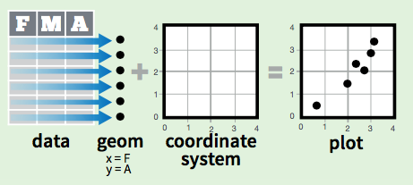

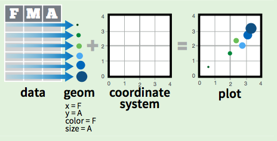

En `ggplot2` se construye la gráfica agregando diferentes capas o `layers`, diferentes tipos de capas que se trataran en este curso son:

1. Aesthetic: `aes()` propiedades de objetos por mapear en la gráfica (axis x, axis y, size, shape, color, fill).
2. Geoms: `geom_` Objetos geométricos. Estos objetos se dividen en objetos que mapean en una dimensión, dos dimensiones y tres dimensiones.
3. Transformaciones estadísticas: `stat_` Resúmen estadístico de variables.
4. Facets: `facet_` División de gráficas en diferentes paneles o subgráficas.
5. Themes: `theme()` Aspectos de la gráfica independientes de los datos, como: fuente, títulos, posición de leyendas y fondo.

Existen dos funciones para graficar: `ggplot` y `qplot`. Aunque `qplot` es muy sencilla y similar a `plot`, en este curso se pondrá especial antención a la función `ggplot`.

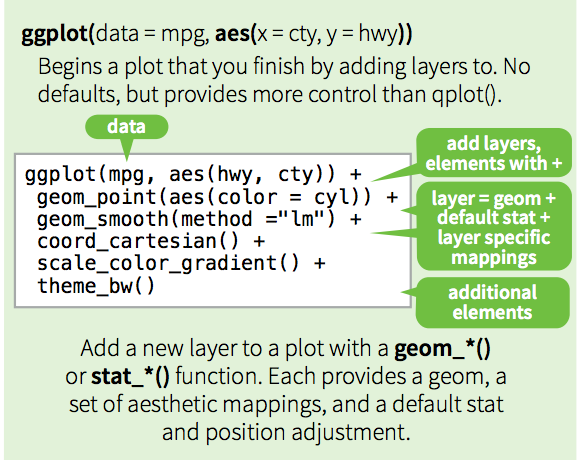

Se seguirá el siguiente orden para ejemplificar distintas gráficas:

- Gráfica de dispersión
- Páneles
- Histogramas
- Barras
- Box-plot

#### Gráficas de dispersión (sactterplots)

Para este ejemplo se usa la base de datos `mpg` la cual tiene datos de 38 modelos de autos

```r
head(mpg)
```

| manufacturer | model | displ | year | cyl | trans | drv | cty | hwy | fl | class |
| --- | --- | --- | --- | --- | --- | --- | --- | --- | --- | --- |
| audi | a4 | 1.8 | 1999 | 4 | auto(l5) | f | 18 | 29 | p | compact |
| audi | a4 | 1.8 | 1999 | 4 | manual(m5) | f | 21 | 29 | p | compact |
| audi | a4 | 2.0 | 2008 | 4 | manual(m6) | f | 20 | 31 | p | compact |
| audi | a4 | 2.0 | 2008 | 4 | auto(av) | f | 21 | 30 | p | compact |
| audi | a4 | 2.8 | 1999 | 6 | auto(l5) | f | 16 | 26 | p | compact |
| audi | a4 | 2.8 | 1999 | 6 | manual(m5) | f | 18 | 26 | p | compact |

```r
summary(mpg)
```

```
 manufacturer          model               displ            year
 Length:234         Length:234         Min.   :1.600   Min.   :1999
 Class :character   Class :character   1st Qu.:2.400   1st Qu.:1999
 Mode  :character   Mode  :character   Median :3.300   Median :2004
                                       Mean   :3.472   Mean   :2004
                                       3rd Qu.:4.600   3rd Qu.:2008
                                       Max.   :7.000   Max.   :2008
      cyl           trans               drv                 cty
 Min.   :4.000   Length:234         Length:234         Min.   : 9.00
 1st Qu.:4.000   Class :character   Class :character   1st Qu.:14.00
 Median :6.000   Mode  :character   Mode  :character   Median :17.00
 Mean   :5.889                                         Mean   :16.86
 3rd Qu.:8.000                                         3rd Qu.:19.00
 Max.   :8.000                                         Max.   :35.00
      hwy             fl               class
 Min.   :12.00   Length:234         Length:234
 1st Qu.:18.00   Class :character   Class :character
 Median :24.00   Mode  :character   Mode  :character
 Mean   :23.44
 3rd Qu.:27.00
 Max.   :44.00
```

```r
str(mpg)
```

```
Classes 'tbl_df', 'tbl' and 'data.frame':   234 obs. of  11 variables:
 $ manufacturer: chr  "audi" "audi" "audi" "audi" ...
 $ model       : chr  "a4" "a4" "a4" "a4" ...
 $ displ       : num  1.8 1.8 2 2 2.8 2.8 3.1 1.8 1.8 2 ...
 $ year        : int  1999 1999 2008 2008 1999 1999 2008 1999 1999 2008 ...
 $ cyl         : int  4 4 4 4 6 6 6 4 4 4 ...
 $ trans       : chr  "auto(l5)" "manual(m5)" "manual(m6)" "auto(av)" ...
 $ drv         : chr  "f" "f" "f" "f" ...
 $ cty         : int  18 21 20 21 16 18 18 18 16 20 ...
 $ hwy         : int  29 29 31 30 26 26 27 26 25 28 ...
 $ fl          : chr  "p" "p" "p" "p" ...
 $ class       : chr  "compact" "compact" "compact" "compact" ...
```

```r
?mpg
```

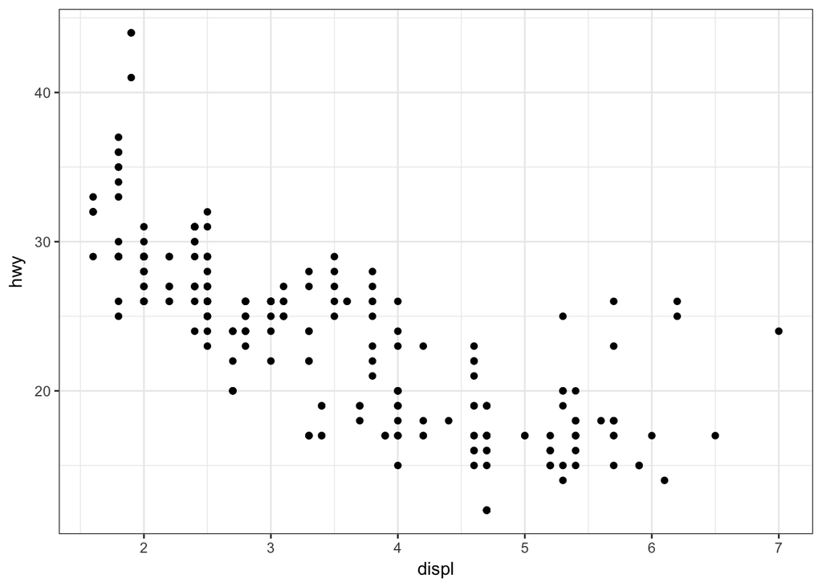

```r
theme_set(theme_bw())
ggplot(data = mpg, aes(x = displ, y = hwy))+
  geom_point()
```

#### Ejercicios

- Correr `ggplot(data = mpg)`
- ¿Cuántas filas hay en `mtcars`?¿Cuántas columnas?
- La variable `drv`, ¿qué describe? (`?mpg)
- Hacer un scatterplot of `hwy` vs `cyl` _ ¿Qué pasa si haces un scatterplot de `class` vs `drv`?

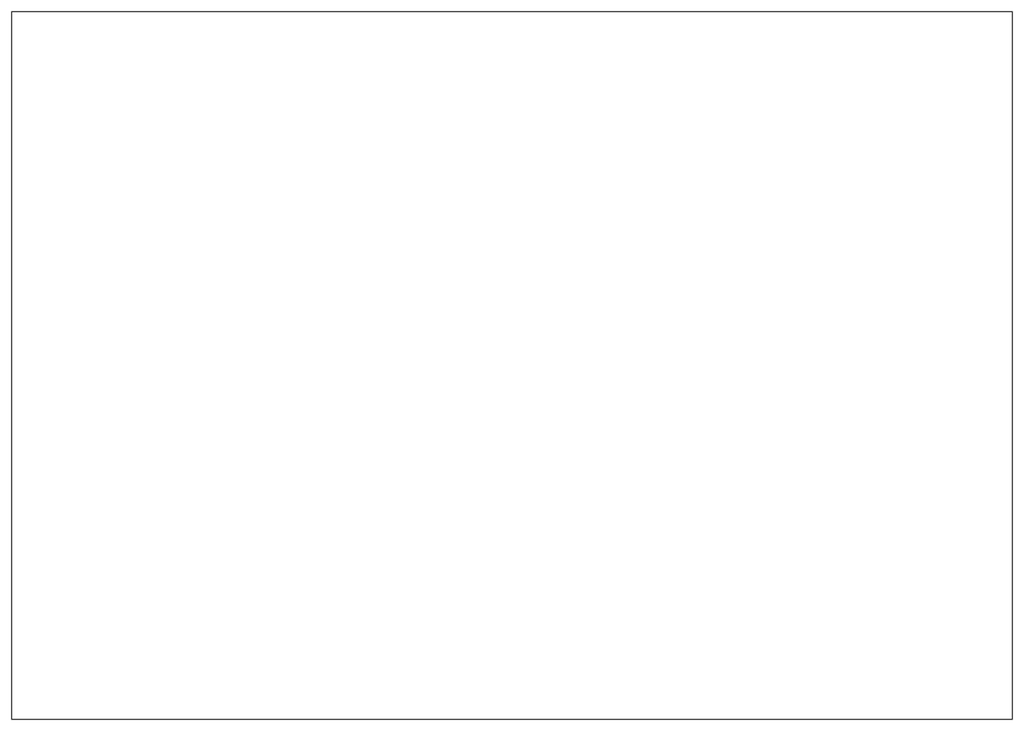

```r
#1
ggplot(mpg)
```

```r
#2
nrow(mtcars)
```

```
[1] 32
```

```r
ncol(mtcars)
```

```
[1] 11
```

```r
#3
?mpg
```

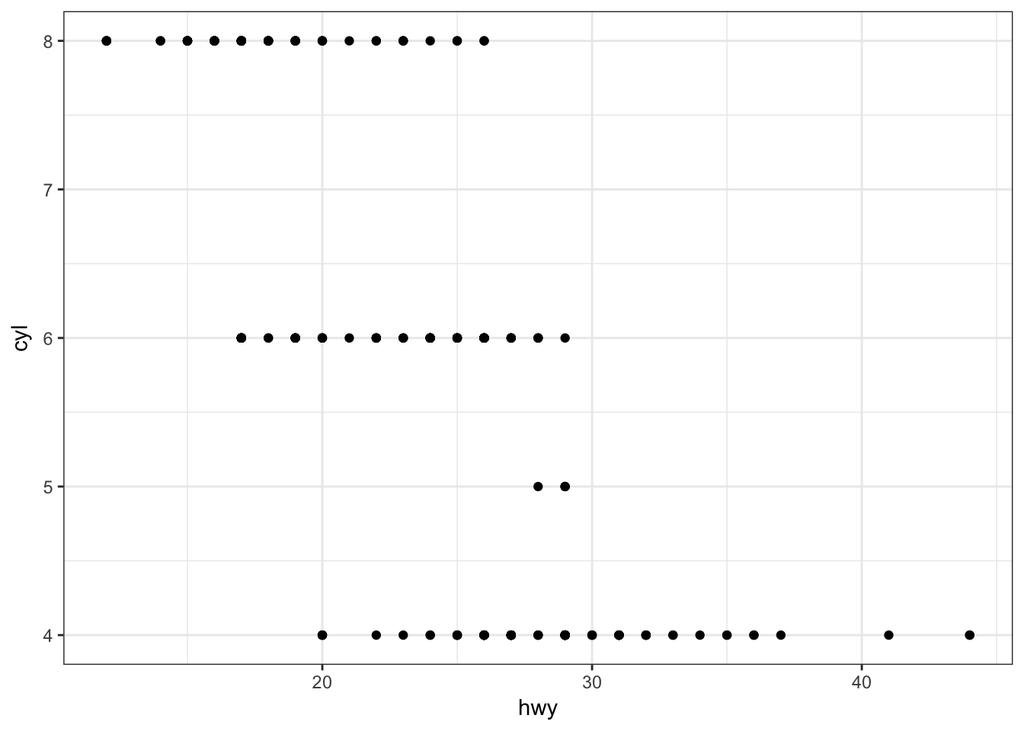

```r
#4
ggplot(mpg,aes(x = hwy, y = cyl)) + geom_point()
```

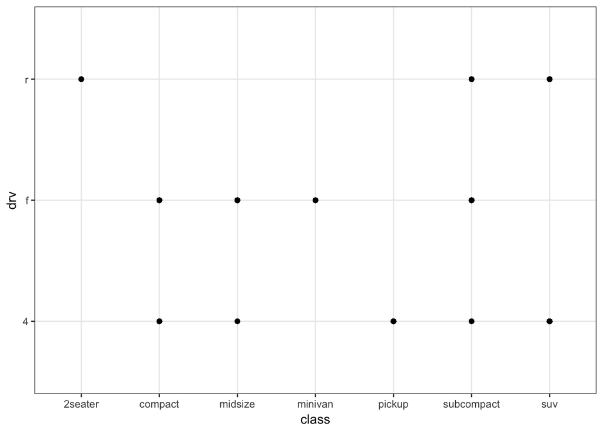

```r
#5
ggplot(mpg,aes(x = class, y = drv)) + geom_point()
```

Podemos representar variables adicionales usando otras características estéticas (aesthetics) como forma, color o tamaño.

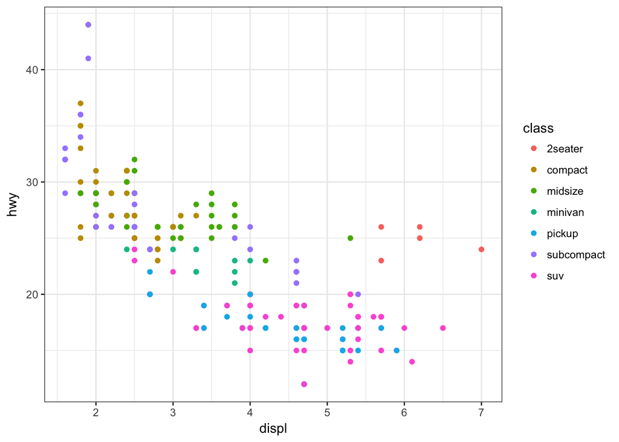

```r
ggplot(mpg, aes(x = displ, y = hwy, color = class)) +
  geom_point()
```

Ahora se prueba con otras variables estéticas.

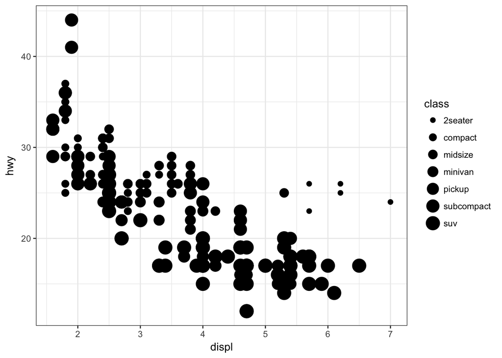

```r
ggplot(mpg, aes(x = displ, y = hwy, size = class)) +
  geom_point()
```

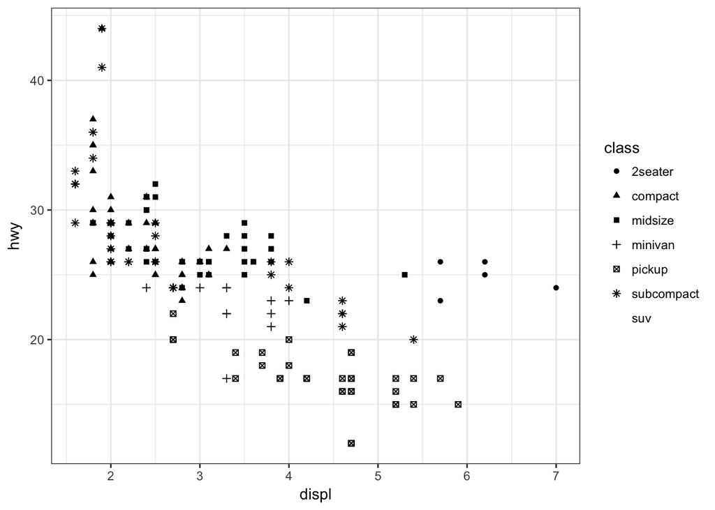

```r
ggplot(mpg, aes(x = displ, y = hwy, shape = class)) +
  geom_point()
```

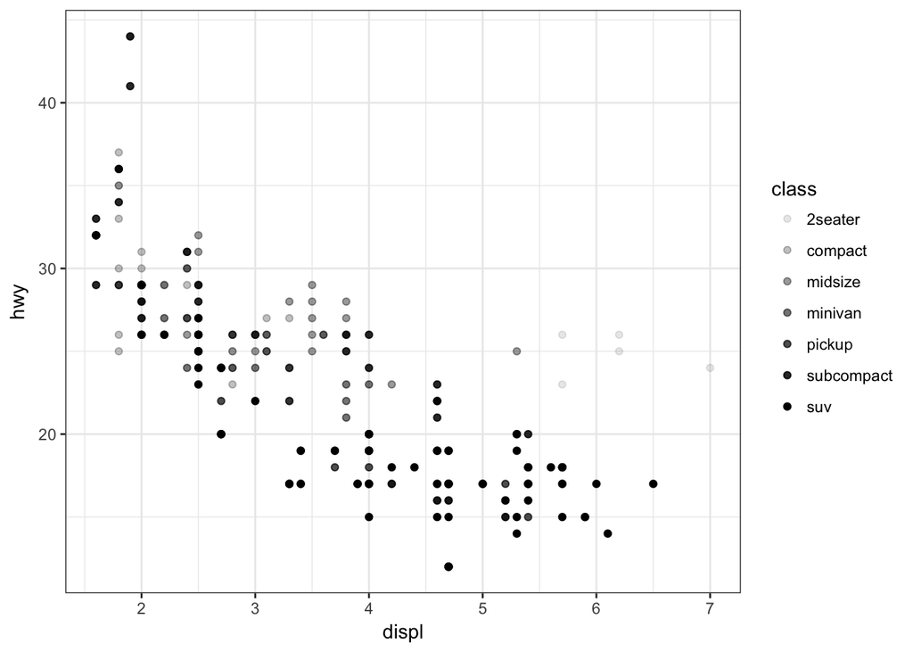

```r
ggplot(mpg, aes(x = displ, y = hwy, alpha = class)) +
  geom_point()
```

Se aprecia que no hay suficientes figuras para todos los valores de `class` `ggplot` 6 figuras. En estos casos se recomienda usar otra opción.

Agregando valores estéticos podemos graficar hasta 5 variables en una sola gráfica.

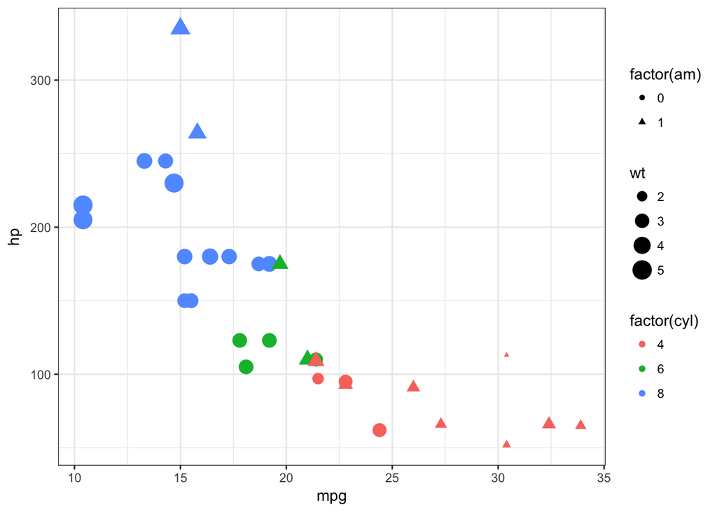

```r
ggplot(mtcars, aes(x=mpg, y = hp))+
  geom_point(aes(color=factor(cyl), size=wt, shape = factor(am)))
```